# Florida COVID-19 Trajectory

Roy Williams, Gabriel J. Odom, Zoran Bursac, and Mary Jo Trepka

21 July 2020

# Introduction

Public understanding of science is critical in times of crisis. The following analysis was conducted to examine the trajectory of COVID-19 in Florida. For phased reopening, the White House has set guidelines for local municipalities in their “Opening Up American Again” report. In the report, it is highly suggested that:

1. Local areas show a downward trajectory in the number of positive cases as a percent of total tests over a two-week period, and
2. Local hospitals have capacity to handle all patients without crisis care.

The analysis begins by looking at the number of new positive cases each day and the number of total tests performed each day. The figures are presented together because **as there is more testing, there are likely to be more positive test results**. Therefore, the proportion of positive cases is also calculated. Given either a flat or increasing number of tests performed, **the proportion of positive cases is the key metric to be used when looking at epidemic trajectory**. It is recommended that this proportion not exceed 5%.

# COVID-19 Test Counts and Proportions

## Full Data

This is a table of the most recent data we have available. We include data sources at the end of the document.

| Date | Positive | Negative | Percent | Total | PropPositive |
| --- | --- | --- | --- | --- | --- |
| 7-Jun | 1516 | 26419 | 5.4 | 27935 | 5.426884 |
| 8-Jun | 1812 | 30848 | 5.5 | 32660 | 5.548071 |
| 9-Jun | 1791 | 22038 | 7.5 | 23829 | 7.516052 |
| 10-Jun | 2298 | 29117 | 7.3 | 31415 | 7.314977 |
| 11-Jun | 2292 | 32271 | 6.6 | 34563 | 6.631369 |
| 12-Jun | 3479 | 36301 | 8.7 | 39780 | 8.745601 |
| 13-Jun | 2700 | 47699 | 5.4 | 50399 | 5.357249 |
| 14-Jun | 1765 | 31912 | 5.2 | 33677 | 5.240966 |
| 15-Jun | 2692 | 34570 | 7.2 | 37262 | 7.224518 |
| 16-Jun | 2410 | 21546 | 10.1 | 23956 | 10.060110 |
| 17-Jun | 2692 | 28047 | 8.8 | 30739 | 8.757604 |
| 18-Jun | 3301 | 30098 | 9.9 | 33399 | 9.883529 |
| 19-Jun | 4007 | 28701 | 12.3 | 32708 | 12.250825 |
| 20-Jun | 4636 | 34568 | 11.8 | 39204 | 11.825324 |
| 21-Jun | 2761 | 32917 | 7.7 | 35678 | 7.738663 |
| 22-Jun | 3829 | 32471 | 10.5 | 36300 | 10.548209 |
| 23-Jun | 5482 | 29171 | 15.8 | 34653 | 15.819698 |
| 24-Jun | 5019 | 50787 | 9.0 | 55806 | 8.993657 |
| 25-Jun | 8871 | 59318 | 13.0 | 68189 | 13.009430 |
| 26-Jun | 9571 | 65922 | 12.7 | 75493 | 12.677997 |
| 27-Jun | 8375 | 60687 | 12.1 | 69062 | 12.126785 |
| 28-Jun | 5380 | 34372 | 13.5 | 39752 | 13.533910 |
| 29-Jun | 6043 | 35396 | 14.6 | 41439 | 14.582881 |
| 30-Jun | 6569 | 36718 | 15.2 | 43287 | 15.175457 |
| 1-Jul | 9477 | 55469 | 14.6 | 64946 | 14.592123 |
| 2-Jul | 9406 | 53471 | 15.0 | 62877 | 14.959365 |
| 3-Jul | 11384 | 69066 | 14.2 | 80450 | 14.150404 |
| 4-Jul | 9920 | 56060 | 15.0 | 65980 | 15.034859 |
| 5-Jul | 6269 | 35582 | 15.0 | 41851 | 14.979331 |
| 6-Jul | 7301 | 37419 | 16.3 | 44720 | 16.326029 |
| 7-Jul | 9988 | 60054 | 14.3 | 70042 | 14.260015 |
| 8-Jul | 8935 | 39305 | 18.5 | 48240 | 18.521974 |
| 9-Jul | 11316 | 77046 | 12.8 | 88362 | 12.806410 |
| 10-Jul | 10333 | 70934 | 12.7 | 81267 | 12.714878 |
| 11-Jul | 15228 | 119493 | 11.3 | 134721 | 11.303360 |
| 12-Jul | 12266 | 93930 | 11.6 | 106196 | 11.550341 |
| 13-Jul | 9255 | 52084 | 15.1 | 61339 | 15.088280 |
| 14-Jul | 10054 | 63824 | 13.6 | 73878 | 13.608923 |
| 15-Jul | 13835 | 92755 | 13.0 | 106590 | 12.979642 |
| 16-Jul | 11285 | 84151 | 11.8 | 95436 | 11.824678 |
| 17-Jul | 10243 | 74091 | 12.1 | 84334 | 12.145754 |
| 18-Jul | 12485 | 93059 | 11.8 | 105544 | 11.829190 |
| 19-Jul | 10506 | 60734 | 14.7 | 71240 | 14.747333 |
| 20-Jul | 9373 | 59431 | 13.6 | 68804 | 13.622754 |

## Total COVID-19 Tests by Day

We see the following pattern for the count of total tests over the past two months (shown on a log scale):

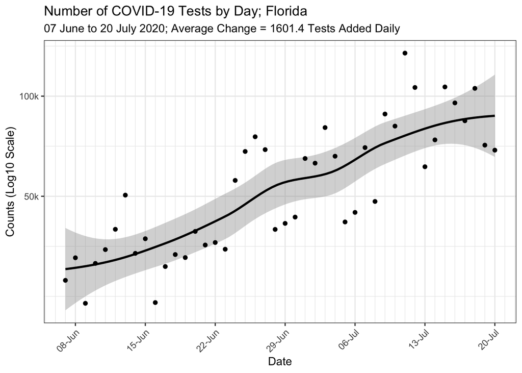

The average number of COVID-19 tests performed each day has increased from under 35,000 in early June to almost 100,000 currently. On average, from 07 June until 20 July, there was an increase of approximately 1601 addition tests performed each day over the previous day. This data is presented on a log scale.

## Positive COVID-19 Tests by Day

We see the following pattern for the count of positive tests over the past two months:

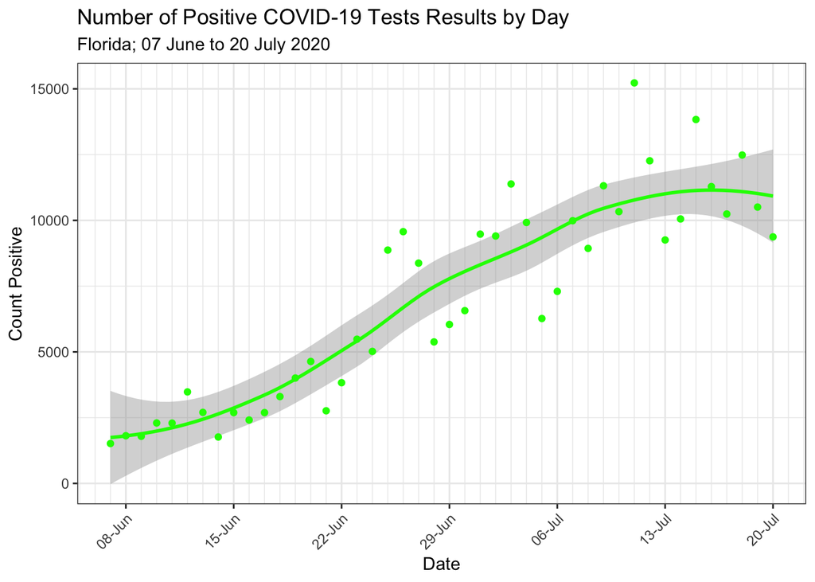

### Positive COVID-19 Tests within the Past Two Weeks

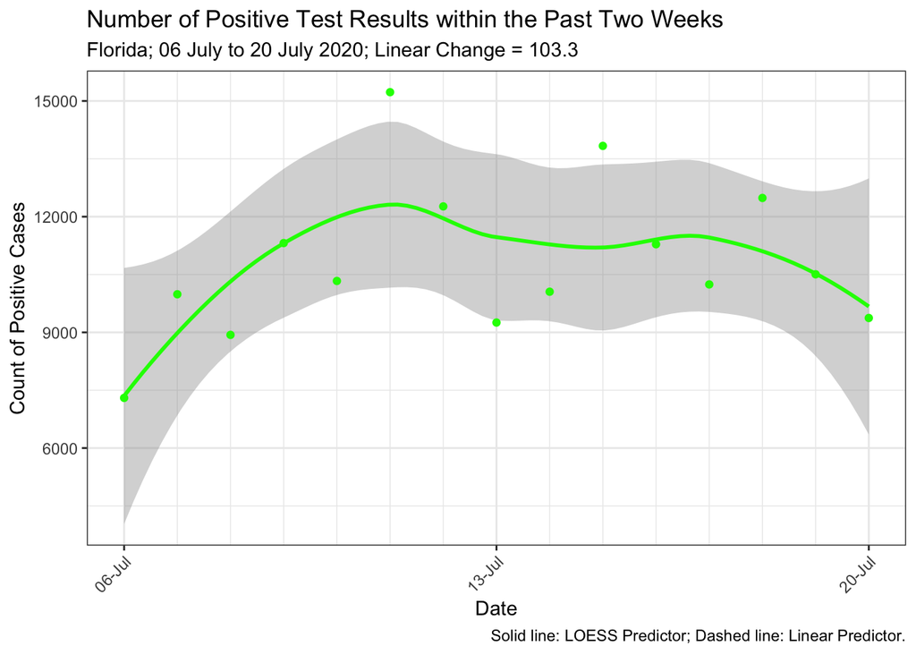

## Proportion of Positive Cases within Past Two Weeks

The proportion of positive COVID-19 tests for the past two weeks is:

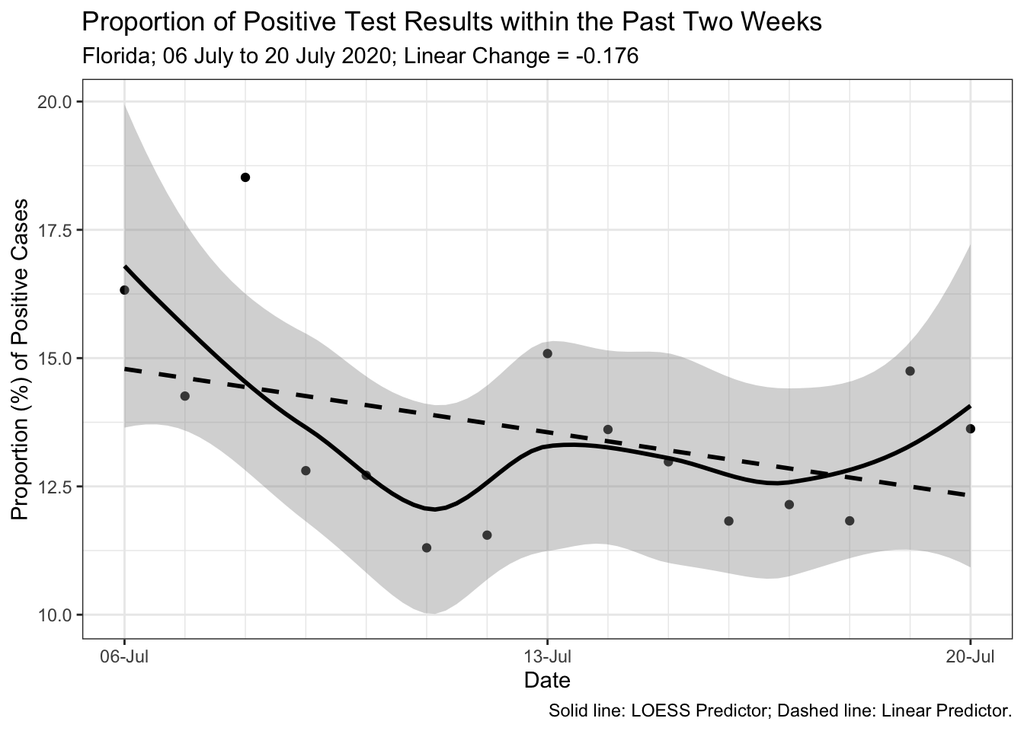

During the 14-day period from 06 July to 20 July, there was a **decrease** in the proportion of positive COVID-19 cases reported in Florida. During this time, there was an average increase of -0.2% per day for new positive cases. Given a flat or increasing number of tests performed, the proportion of positive tests obtained is the **key metric** for examining COVID-19 trajectory. **The percentage of positive test results obtained has exceeded the 5% positive threshold recommended by the World Health Organization (WHO) for reopening.**

## Proportion of Positive COVID-19 Tests by Day

These are the proportions of positive COVID-19 tests for the since the second week of June:

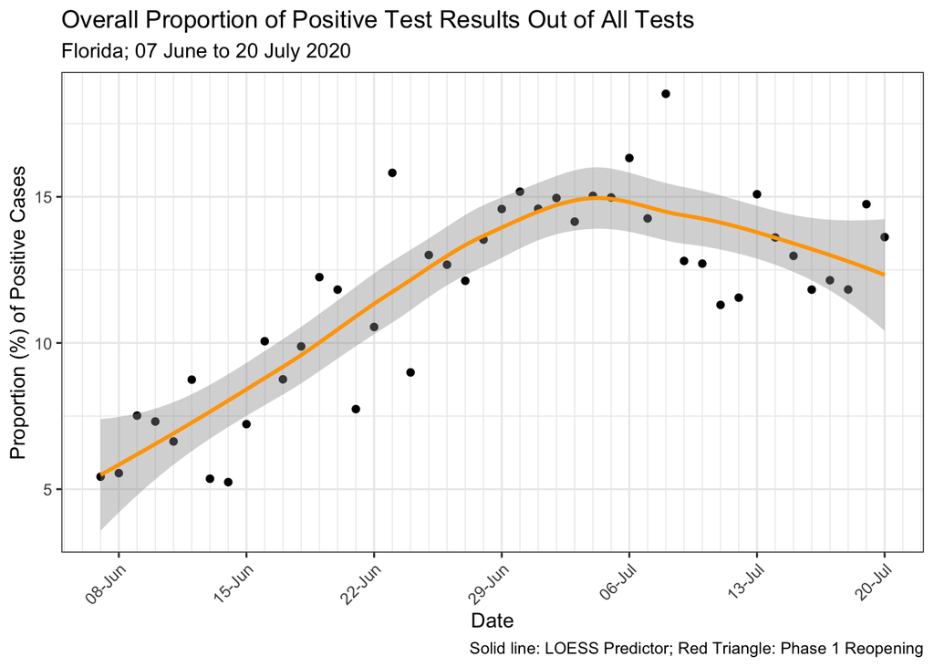

# COVID-19 Deaths by Day

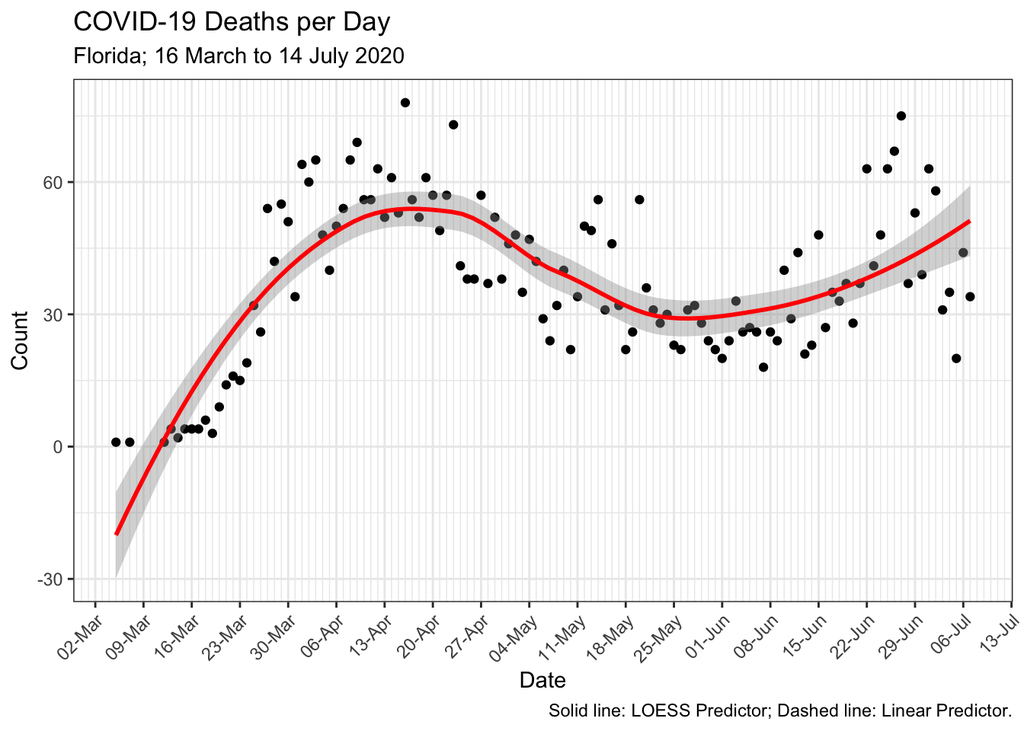

Overall, deaths for Florida increased until mid April highs. Subsequently, there was a decline until approximately the first week of June. Afterwards, there has been an increase in the number of deaths per day for Florida, returning to highs observed in mid April.

**Note: Due to delays in classifying the cause of death and thus of reporting deaths due to COVID-19, the most recent data will undercount the number of deaths. For this reason, the last two weeks were excluded from this analysis of deaths.**

# Conclusion

During the past two weeks, the number of positive COVID-19 tests obtained has increased by an average of 103 each day. **Additionally, there has been a substantial increase in the proportion of positive COVID-19 tests obtained from about 5% in early June. The proportion of positive tests obtained has been consistently greater than 10% since June 25th.** This evidence points to increased community spread of COVID-19 in Florida and represents a significant concern for the state.

# Data Sources

Data sources are as follows:

- **COVID-19 Test Results**: The number of positive and negative COVID-19 test results come from the Florida Department of Health: https://floridahealthcovid19.gov.
- **COVID-19 Hospital Census**: The hospitalization data is disseminated by Florida’s Agency for Health Care Administration: https://ahca.myflorida.com.
- **COVID-19 Death Linelist**: This list is created and disseminated by Florida’s Department of Health. Deaths are medical examiner confirmed. https://floridahealthcovid19.gov.

[GitHub](https://github.com/Rwilli5/MiamiCovidProject/)